# Seagrant ME-NH trawl survey Objective 2: Analysis of similarity and Analysis of variance

### Year

```r
#Time
ano_year<- anosim(trawl_dist, trawl_data_arrange$Year, permutations = 999)
ano_year #years are statistically different communities
```

```
##
## Call:
## anosim(x = trawl_dist, grouping = trawl_data_arrange$Year, permutations = 999)
## Dissimilarity: bray
##
## ANOSIM statistic R: 0.1252
##       Significance: 0.001
##
## Permutation: free
## Number of permutations: 999
```

```r
summary(ano_year)
```

```
##
## Call:
## anosim(x = trawl_dist, grouping = trawl_data_arrange$Year, permutations = 999)
## Dissimilarity: bray
##
## ANOSIM statistic R: 0.1252
##       Significance: 0.001
##
## Permutation: free
## Number of permutations: 999
##
## Upper quantiles of permutations (null model):
##    90%    95%  97.5%    99%
## 0.0192 0.0265 0.0305 0.0370
##
## Dissimilarity ranks between and within classes:
##           0%     25%     50%      75%  100%     N
## Between    1 4812.25  9534.5 14222.75 18915 18050
## 2000     217 4819.50  6612.5  9320.00 13344    10
## 2001     525 5418.00 12824.0 16868.00 18217    45
## 2002     619 6225.00 11209.0 13296.00 17389    45
## 2003      99 5655.00 10274.0 15244.00 18230    45
## 2004     260 9688.00 15280.0 17844.00 18887    45
## 2005     567 6315.00 10597.0 15396.00 18738    45
## 2006     198 6976.00 12562.0 15194.00 18221    45
## 2007    2131 9788.00 15651.0 17493.00 18900    45
## 2008     559 6095.00 11538.0 16202.00 18430    45
## 2009     266 5985.00 10139.0 12380.00 16642    45
## 2010      58 2203.00  6548.0  9759.00 14837    45
## 2011     457 4235.00 10369.0 13419.00 17082    45
## 2012     133 1364.00  3343.0  4590.00 10153    45
## 2013      18  795.00  2333.0  3796.00 11260    45
## 2014       6 1516.00  4963.0  9125.00 16084    45
## 2015     380 3017.00  5877.0 10700.00 17347    45
## 2016      70 1749.00  4757.0  7694.00 14871    45
## 2017      35 1168.00  4137.0  7191.00 14935    45
## 2018      12 3428.00  9051.0 13573.00 17500    45
## 2019      16 1930.00  4588.0  9241.00 16238    45
```

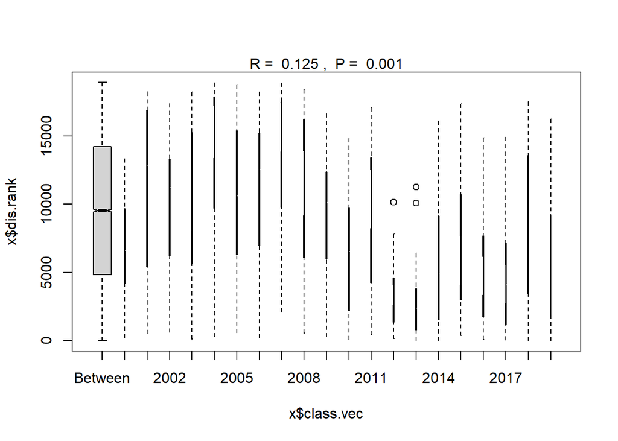

```r
plot(ano_year)
```

### Year blocks

```r
#Year blocks
ano_year_blocks<- anosim(trawl_dist, trawl_data_arrange$YEAR_GROUPS, permutations = 999)
ano_year_blocks #years are statistically different communities
```

```
##
## Call:
## anosim(x = trawl_dist, grouping = trawl_data_arrange$YEAR_GROUPS,      permutations = 999)
## Dissimilarity: bray
##
## ANOSIM statistic R: 0.1698
##       Significance: 0.001
##
## Permutation: free
## Number of permutations: 999
```

```r
summary(ano_year_blocks)
```

```
##
## Call:
## anosim(x = trawl_dist, grouping = trawl_data_arrange$YEAR_GROUPS,      permutations = 999)
## Dissimilarity: bray
##
## ANOSIM statistic R: 0.1698
##       Significance: 0.001
##
## Permutation: free
## Number of permutations: 999
##
## Upper quantiles of permutations (null model):
##    90%    95%  97.5%    99%
## 0.0096 0.0125 0.0152 0.0205
##
## Dissimilarity ranks between and within classes:
##           0%     25%   50%      75%  100%     N
## Between    1 5308.25  9966 14517.50 18915 14250
## 2000-2004 54 5768.50 11052 15452.75 18913   990
## 2005-2009 15 6208.00 11413 15720.00 18909  1225
## 2010-2014  6 2086.00  4807  8907.00 17501  1225
## 2015-2019  3 2053.00  5370 10302.00 18480  1225
```

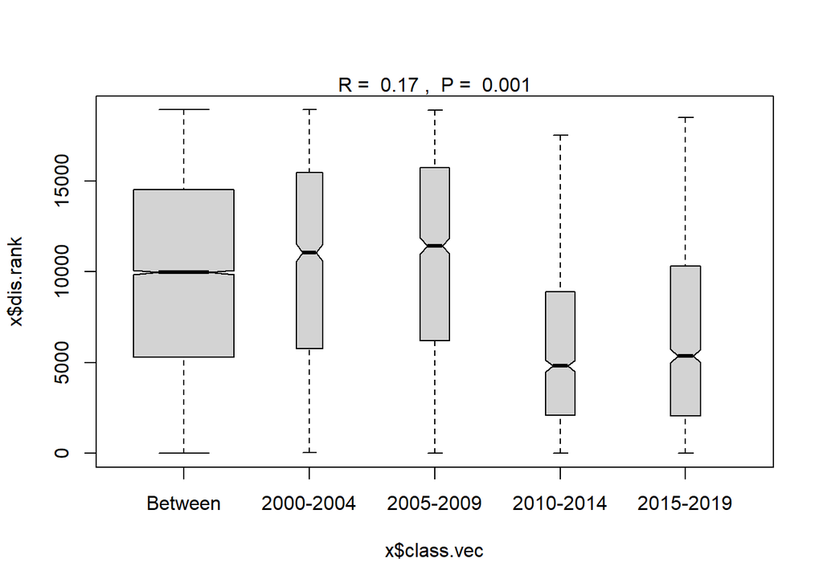

```r
plot(ano_year_blocks)
```

## Analysis of variance (Adonis)

- Permanova
- tests whether there is a difference between means of groups
- works by calculating the sum of squares from the centroid of the group

### Region and Year

```r
adonis<-adonis2(trawl_dist~Region*Year, data=ME_group_data, by="terms", permutations = 9999)
adonis
```

```
## Permutation test for adonis under reduced model
## Terms added sequentially (first to last)
## Permutation: free
## Number of permutations: 9999
##
## adonis2(formula = trawl_dist ~ Region * Year, data = ME_group_data, permutations = 9999, by = "terms")
##              Df SumOfSqs      R2       F Pr(>F)
## Region        1   2.4733 0.08292 19.3464  1e-04 ***
## Year          1   2.3702 0.07947 18.5400  1e-04 ***
## Region:Year   1   0.5655 0.01896  4.4233  4e-04 ***
## Residual    191  24.4176 0.81865
## Total       194  29.8265 1.00000
## ---
## Signif. codes:  0 '***' 0.001 '**' 0.01 '*' 0.05 '.' 0.1 ' ' 1
```

```r
summary(adonis)
```

```
##        Df           SumOfSqs             R2                F
##  Min.   :  1.0   Min.   : 0.5655   Min.   :0.01896   Min.   : 4.423
##  1st Qu.:  1.0   1st Qu.: 2.3702   1st Qu.:0.07947   1st Qu.:11.482
##  Median :  1.0   Median : 2.4733   Median :0.08292   Median :18.540
##  Mean   : 77.6   Mean   :11.9306   Mean   :0.40000   Mean   :14.103
##  3rd Qu.:191.0   3rd Qu.:24.4176   3rd Qu.:0.81865   3rd Qu.:18.943
##  Max.   :194.0   Max.   :29.8265   Max.   :1.00000   Max.   :19.346
##                                                      NA's   :2
##      Pr(>F)
##  Min.   :0.00010
##  1st Qu.:0.00010
##  Median :0.00010
##  Mean   :0.00020
##  3rd Qu.:0.00025
##  Max.   :0.00040
##  NA's   :2
```

### Region and year block

```r
#with year blocks
adonis<-adonis2(trawl_dist~Region*YEAR_GROUPS, data=ME_group_data, by="terms", permutations = 9999)
adonis
```

```
## Permutation test for adonis under reduced model
## Terms added sequentially (first to last)
## Permutation: free
## Number of permutations: 9999
##
## adonis2(formula = trawl_dist ~ Region * YEAR_GROUPS, data = ME_group_data, permutations = 9999, by = "terms")
##                     Df SumOfSqs      R2       F Pr(>F)
## Region               1   2.4733 0.08292 20.0943  1e-04 ***
## YEAR_GROUPS          3   3.3389 0.11194  9.0424  1e-04 ***
## Region:YEAR_GROUPS   3   0.9979 0.03346  2.7024  2e-04 ***
## Residual           187  23.0164 0.77168
## Total              194  29.8265 1.00000
## ---
## Signif. codes:  0 '***' 0.001 '**' 0.01 '*' 0.05 '.' 0.1 ' ' 1
```

```r
summary(adonis)
```

```
##        Df           SumOfSqs             R2                F
##  Min.   :  1.0   Min.   : 0.9979   Min.   :0.03346   Min.   : 2.702
##  1st Qu.:  3.0   1st Qu.: 2.4733   1st Qu.:0.08292   1st Qu.: 5.872
##  Median :  3.0   Median : 3.3389   Median :0.11194   Median : 9.042
##  Mean   : 77.6   Mean   :11.9306   Mean   :0.40000   Mean   :10.613
##  3rd Qu.:187.0   3rd Qu.:23.0164   3rd Qu.:0.77168   3rd Qu.:14.568
##  Max.   :194.0   Max.   :29.8265   Max.   :1.00000   Max.   :20.094
##                                                      NA's   :2
##      Pr(>F)
##  Min.   :0.0001000
##  1st Qu.:0.0001000
##  Median :0.0001000
##  Mean   :0.0001333
##  3rd Qu.:0.0001500
##  Max.   :0.0002000
##  NA's   :2
```

## Pairwise

- Vegan does not have a function for this, but I found a wrapper that seems frequently used on github
- select groups to test, one pair at a time
- Adjust p-values for multiple tests

### Region

```r
#pair-wise test to see what is different
pair<-pairwise.adonis2(trawl_dist~Region, data=ME_group_data, by="terms", permutations = 9999)
summary(pair)
```

```
##             Length Class  Mode
## parent_call 1      -none- character
## 1_vs_2      6      anova  list
## 1_vs_3      6      anova  list
## 1_vs_4      6      anova  list
## 1_vs_5      6      anova  list
## 2_vs_3      6      anova  list
## 2_vs_4      6      anova  list
## 2_vs_5      6      anova  list
## 3_vs_4      6      anova  list
## 3_vs_5      6      anova  list
## 4_vs_5      6      anova  list
```

```r
pair #shows all the regions are significantly different except 3 and 4
```

```
## $parent_call
## [1] "trawl_dist ~ Region , strata = Null"
##
## $`1_vs_2`
## Permutation: free
## Number of permutations: 9999
##
## Terms added sequentially (first to last)
##
##           Df SumsOfSqs MeanSqs F.Model      R2 Pr(>F)
## Region     1    1.1374 1.13737  7.9949 0.09518  1e-04 ***
## Residuals 76   10.8119 0.14226         0.90482
## Total     77   11.9492                 1.00000
## ---
## Signif. codes:  0 '***' 0.001 '**' 0.01 '*' 0.05 '.' 0.1 ' ' 1
##
## $`1_vs_3`
## Permutation: free
## Number of permutations: 9999
##
## Terms added sequentially (first to last)
##
##           Df SumsOfSqs MeanSqs F.Model      R2 Pr(>F)
## Region     1    1.8898 1.88977  14.078 0.15629  1e-04 ***
## Residuals 76   10.2019 0.13424         0.84371
## Total     77   12.0917                 1.00000
## ---
## Signif. codes:  0 '***' 0.001 '**' 0.01 '*' 0.05 '.' 0.1 ' ' 1
##
## $`1_vs_4`
## Permutation: free
## Number of permutations: 9999
##
## Terms added sequentially (first to last)
##
##           Df SumsOfSqs MeanSqs F.Model      R2 Pr(>F)
## Region     1    2.2077 2.20767  15.829 0.17237  1e-04 ***
## Residuals 76   10.5999 0.13947         0.82763
## Total     77   12.8076                 1.00000
## ---
```

[output cut: 80 more lines]

```
## $`4_vs_5`
## Permutation: free
## Number of permutations: 9999
##
## Terms added sequentially (first to last)
##
##           Df SumsOfSqs MeanSqs F.Model      R2 Pr(>F)
## Region     1    1.2815 1.28154  10.542 0.12181  1e-04 ***
## Residuals 76    9.2392 0.12157         0.87819
## Total     77   10.5207                 1.00000
## ---
## Signif. codes:  0 '***' 0.001 '**' 0.01 '*' 0.05 '.' 0.1 ' ' 1
##
## attr(,"class")
## [1] "pwadstrata" "list"
```

### Year blocks

```r
#pair-wise test to see what is different for year blocks
pair<-pairwise.adonis2(trawl_dist~YEAR_GROUPS, data=ME_group_data, by="terms", permutations = 9999)
summary(pair)
```

```
##                        Length Class  Mode
## parent_call            1      -none- character
## 2000-2004_vs_2005-2009 6      anova  list
## 2000-2004_vs_2010-2014 6      anova  list
## 2000-2004_vs_2015-2019 6      anova  list
## 2005-2009_vs_2010-2014 6      anova  list
## 2005-2009_vs_2015-2019 6      anova  list
## 2010-2014_vs_2015-2019 6      anova  list
```

```r
pair
```

```
## $parent_call
## [1] "trawl_dist ~ YEAR_GROUPS , strata = Null"
##
## $`2000-2004_vs_2005-2009`
## Permutation: free
## Number of permutations: 9999
##
## Terms added sequentially (first to last)
##
##             Df SumsOfSqs MeanSqs F.Model      R2 Pr(>F)
## YEAR_GROUPS  1    0.5499 0.54989  3.1888 0.03315 0.0036 **
## Residuals   93   16.0372 0.17244         0.96685
## Total       94   16.5871                 1.00000
## ---
## Signif. codes:  0 '***' 0.001 '**' 0.01 '*' 0.05 '.' 0.1 ' ' 1
##
## $`2000-2004_vs_2010-2014`
## Permutation: free
## Number of permutations: 9999
##
## Terms added sequentially (first to last)
##
##             Df SumsOfSqs MeanSqs F.Model      R2 Pr(>F)
## YEAR_GROUPS  1    1.1475 1.14748  8.5301 0.08402  1e-04 ***
## Residuals   93   12.5104 0.13452         0.91598
## Total       94   13.6579                 1.00000
## ---
## Signif. codes:  0 '***' 0.001 '**' 0.01 '*' 0.05 '.' 0.1 ' ' 1
##
## $`2000-2004_vs_2015-2019`
## Permutation: free
## Number of permutations: 9999
##
## Terms added sequentially (first to last)
##
##             Df SumsOfSqs MeanSqs F.Model      R2 Pr(>F)
## YEAR_GROUPS  1    1.7906 1.79056  12.878 0.12163  1e-04 ***
## Residuals   93   12.9309 0.13904         0.87837
## Total       94   14.7215                 1.00000
## ---
```

[output cut: 28 more lines]

```
## $`2010-2014_vs_2015-2019`
## Permutation: free
## Number of permutations: 9999
##
## Terms added sequentially (first to last)
##
##             Df SumsOfSqs MeanSqs F.Model      R2 Pr(>F)
## YEAR_GROUPS  1    0.3126 0.31256  2.9311 0.02904 0.0044 **
## Residuals   98   10.4504 0.10664         0.97096
## Total       99   10.7629                 1.00000
## ---
## Signif. codes:  0 '***' 0.001 '**' 0.01 '*' 0.05 '.' 0.1 ' ' 1
##
## attr(,"class")
## [1] "pwadstrata" "list"
```

## Dispersion

- anosim very sensitive to heterogeneity (Anderson and Walsh 2013)
- Could get false significant results from differences in variance instead of mean
- adonis is less affected by heterogeneity for *balanced designs*
- PRIMER can deal with dispersion issues, but vegan does not yet

### Region

```r
#betadisper test homogeneity of dispersion among groups
#Region
bd<-betadisper(trawl_dist,ME_group_data$Region)
bd
```

```
##
##  Homogeneity of multivariate dispersions
##
## Call: betadisper(d = trawl_dist, group = ME_group_data$Region)
##
## No. of Positive Eigenvalues: 83
## No. of Negative Eigenvalues: 111
##
## Average distance to median:
##      1      2      3      4      5
## 0.3754 0.3522 0.3255 0.3354 0.3214
##
## Eigenvalues for PCoA axes:
## (Showing 8 of 194 eigenvalues)
## PCoA1 PCoA2 PCoA3 PCoA4 PCoA5 PCoA6 PCoA7 PCoA8
## 7.177 4.988 3.828 2.354 1.707 1.515 1.353 1.176
```

```r
anova(bd)
```

```
## Analysis of Variance Table
##
## Response: Distances
##            Df  Sum Sq   Mean Sq F value  Pr(>F)
## Groups      4 0.07648 0.0191204  2.0314 0.09165 .
## Residuals 190 1.78838 0.0094125
## ---
## Signif. codes:  0 '***' 0.001 '**' 0.01 '*' 0.05 '.' 0.1 ' ' 1
```

```r
#test based on permutations
permutest(bd)
```

```
##
## Permutation test for homogeneity of multivariate dispersions
## Permutation: free
## Number of permutations: 999
##
## Response: Distances
##            Df  Sum Sq   Mean Sq      F N.Perm Pr(>F)
## Groups      4 0.07648 0.0191204 2.0314    999  0.086 .
## Residuals 190 1.78838 0.0094125
## ---
## Signif. codes:  0 '***' 0.001 '**' 0.01 '*' 0.05 '.' 0.1 ' ' 1
```

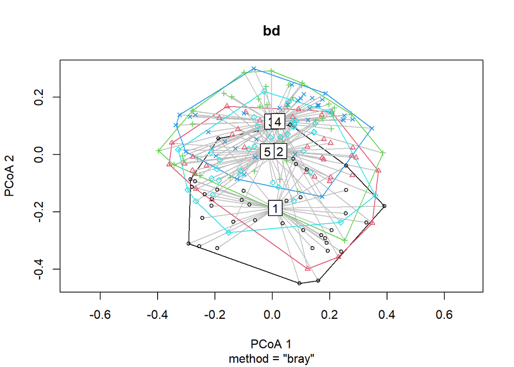

```r
plot(bd)
```

### Year

```r
#Year
bd<-betadisper(trawl_dist,ME_group_data$Year)
bd
```

```
##
##  Homogeneity of multivariate dispersions
##
## Call: betadisper(d = trawl_dist, group = ME_group_data$Year)
##
## No. of Positive Eigenvalues: 83
## No. of Negative Eigenvalues: 111
##
## Average distance to median:
##   2000   2001   2002   2003   2004   2005   2006   2007   2008   2009   2010
## 0.2937 0.3911 0.3688 0.3792 0.4275 0.3783 0.3880 0.4373 0.3760 0.3541 0.3072
##   2011   2012   2013   2014   2015   2016   2017   2018   2019
## 0.3562 0.2519 0.2343 0.2767 0.3180 0.2854 0.2742 0.3512 0.2904
##
## Eigenvalues for PCoA axes:
## (Showing 8 of 194 eigenvalues)
## PCoA1 PCoA2 PCoA3 PCoA4 PCoA5 PCoA6 PCoA7 PCoA8
## 7.177 4.988 3.828 2.354 1.707 1.515 1.353 1.176
```

```r
anova(bd)
```

```
## Analysis of Variance Table
##
## Response: Distances
##            Df  Sum Sq  Mean Sq F value    Pr(>F)
## Groups     19 0.63018 0.033167  3.6271 2.865e-06 ***
## Residuals 175 1.60025 0.009144
## ---
## Signif. codes:  0 '***' 0.001 '**' 0.01 '*' 0.05 '.' 0.1 ' ' 1
```

```r
#test based on permutations
permutest(bd)
```

```
##
## Permutation test for homogeneity of multivariate dispersions
## Permutation: free
## Number of permutations: 999
##
## Response: Distances
##            Df  Sum Sq  Mean Sq      F N.Perm Pr(>F)
## Groups     19 0.63018 0.033167 3.6271    999  0.001 ***
## Residuals 175 1.60025 0.009144
## ---
## Signif. codes:  0 '***' 0.001 '**' 0.01 '*' 0.05 '.' 0.1 ' ' 1
```

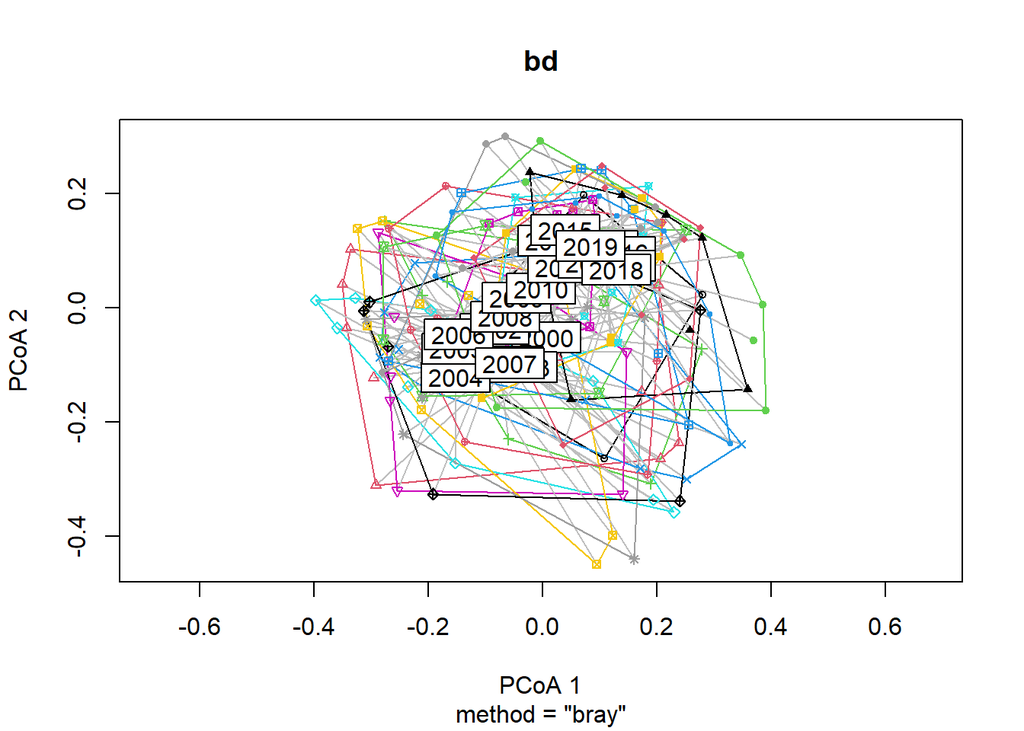

```r
plot(bd)
```

### Year block

```r
#Year blocks
bd<-betadisper(trawl_dist,ME_group_data$YEAR_GROUPS)
bd
```

```
##
##  Homogeneity of multivariate dispersions
##
## Call: betadisper(d = trawl_dist, group = ME_group_data$YEAR_GROUPS)
##
## No. of Positive Eigenvalues: 83
## No. of Negative Eigenvalues: 111
##
## Average distance to median:
## 2000-2004 2005-2009 2010-2014 2015-2019
##    0.3991    0.4011    0.3045    0.3175
##
## Eigenvalues for PCoA axes:
## (Showing 8 of 194 eigenvalues)
## PCoA1 PCoA2 PCoA3 PCoA4 PCoA5 PCoA6 PCoA7 PCoA8
## 7.177 4.988 3.828 2.354 1.707 1.515 1.353 1.176
```

```r
anova(bd)
```

```
## Analysis of Variance Table
##
## Response: Distances
##            Df  Sum Sq  Mean Sq F value    Pr(>F)
## Groups      3 0.39156 0.130521  14.687 1.205e-08 ***
## Residuals 191 1.69735 0.008887
## ---
## Signif. codes:  0 '***' 0.001 '**' 0.01 '*' 0.05 '.' 0.1 ' ' 1
```

```r
#test based on permutations
permutest(bd)
```

```
##
## Permutation test for homogeneity of multivariate dispersions
## Permutation: free
## Number of permutations: 999
##
## Response: Distances
##            Df  Sum Sq  Mean Sq      F N.Perm Pr(>F)
## Groups      3 0.39156 0.130521 14.687    999  0.001 ***
## Residuals 191 1.69735 0.008887
## ---
## Signif. codes:  0 '***' 0.001 '**' 0.01 '*' 0.05 '.' 0.1 ' ' 1
```

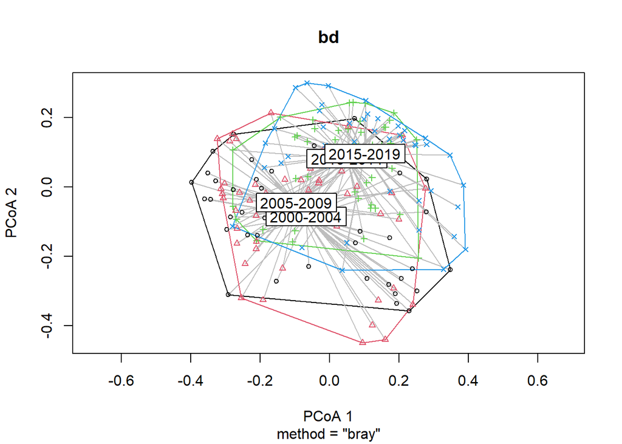

```r
plot(bd)
```

## Indicator species analysis

- test if a species if found significantly more in one group compared to another
- all combinations of groups

### Region

```r
#see which species are found significantly more in each Region
inv_region<-multipatt(ME_NMDS_data, ME_group_data$Region, func = "r.g", control = how(nperm=999))
summary(inv_region)
```

```
##
##  Multilevel pattern analysis
##  ---------------------------
##
##  Association function: r.g
##  Significance level (alpha): 0.05
##
##  Total number of species: 50
##  Selected number of species: 37
##  Number of species associated to 1 group: 17
##  Number of species associated to 2 groups: 15
##  Number of species associated to 3 groups: 3
##  Number of species associated to 4 groups: 2
##
##  List of species associated to each combination:
##
##  Group 1  #sps.  9
##                              stat p.value
## flounder.yellowtail         0.789   0.001 ***
## cod.atlantic                0.517   0.001 ***
## haddock                     0.412   0.001 ***
## dogfish.spiny               0.379   0.001 ***
## hake.atlantic.red           0.280   0.005 **
## mackerel.atlantic           0.219   0.018 *
## squid.long.finned           0.211   0.030 *
## butterfish                  0.210   0.033 *
## redfish.acadian.ocean.perch 0.205   0.001 ***
##
##  Group 2  #sps.  4
##                      stat p.value
## alewife             0.455   0.001 ***
## crab.northern.stone 0.354   0.002 **
## smelt.rainbow       0.340   0.001 ***
## sturgeon.atlantic   0.256   0.007 **
##
##  Group 4  #sps.  3
##               stat p.value
## cucumber.sea 0.224   0.005 **
## scallop.sea  0.205   0.032 *
## crab.green   0.172   0.010 **
```

[output cut: 38 more lines]

```
## herring.atlantic 0.319   0.002 **
##
##  Group 3+4+5  #sps.  1
##                  stat p.value
## halibut.atlantic 0.26   0.002 **
##
##  Group 1+2+3+4  #sps.  1
##                        stat p.value
## hake.silver..whiting. 0.209   0.044 *
##
##  Group 2+3+4+5  #sps.  1
##                   stat p.value
## lobster.american 0.329   0.001 ***
## ---
## Signif. codes:  0 '***' 0.001 '**' 0.01 '*' 0.05 '.' 0.1 ' ' 1
```

### Year block

```r
#see which species are found significantly more in each Region
inv_year<-multipatt(ME_NMDS_data, ME_group_data$YEAR_GROUPS, func = "r.g", control = how(nperm=999))
summary(inv_year)
```

```
##
##  Multilevel pattern analysis
##  ---------------------------
##
##  Association function: r.g
##  Significance level (alpha): 0.05
##
##  Total number of species: 50
##  Selected number of species: 24
##  Number of species associated to 1 group: 14
##  Number of species associated to 2 groups: 8
##  Number of species associated to 3 groups: 2
##
##  List of species associated to each combination:
##
##  Group 2000-2004  #sps.  6
##               stat p.value
## scallop.sea  0.374   0.001 ***
## skate.little 0.321   0.001 ***
## sea.raven    0.318   0.001 ***
## monkfish     0.281   0.001 ***
## skate.winter 0.236   0.005 **
## scup         0.202   0.001 ***
##
##  Group 2005-2009  #sps.  4
##                        stat p.value
## plaice.american..dab. 0.269   0.002 **
## wolffish.atlantic     0.207   0.022 *
## cod.atlantic          0.188   0.040 *
## squid.short.finned    0.184   0.015 *
##
##  Group 2010-2014  #sps.  1
##             stat p.value
## crab.green 0.152   0.009 **
##
##  Group 2015-2019  #sps.  3
##                    stat p.value
## hake.atlantic.red 0.337   0.001 ***
## haddock           0.305   0.002 **
## hake.white        0.303   0.001 ***
```

[output cut: 9 more lines]

```
##  Group 2010-2014+2015-2019  #sps.  3
##                   stat p.value
## lobster.american 0.499   0.001 ***
## skate.barndoor   0.231   0.015 *
## halibut.atlantic 0.230   0.007 **
##
##  Group 2000-2004+2005-2009+2015-2019  #sps.  1
##             stat p.value
## crab.jonah 0.286   0.002 **
##
##  Group 2000-2004+2010-2014+2015-2019  #sps.  1
##                        stat p.value
## hake.silver..whiting. 0.279   0.001 ***
## ---
## Signif. codes:  0 '***' 0.001 '**' 0.01 '*' 0.05 '.' 0.1 ' ' 1
```